# PROBABILITIES

### Flipping coins

This exercise requires the bernoulli object from the scipy.stats library to simulate the two possible outcomes from a coin flip, 1 ("heads") or 0 ("tails"), and the numpy library (loaded as np) to set the random generator seed.

You'll use the bernoulli.rvs() function to simulate coin flips using the size argument.

You will set the random seed so you can reproduce the results for the random experiment in each exercise.

From each experiment, you will get the values of each coin flip. You can add the coin flips to get the number of heads after flipping 10 coins using the sum() function.

Import bernoulli from scipy.stats, set the seed with np.random.seed(). Simulate 1 flip, with a 35% chance of heads.

```python
# Import the bernoulli object from scipy.stats
from scipy.stats import bernoulli
import numpy as np

# Set the random seed to reproduce the results
np.random.seed(42)

# Simulate one coin flip with 35% chance of getting heads
coin_flip = bernoulli.rvs(p=0.35, size=1)
print(coin_flip)
```

```
[0]
```

Use bernoulli.rvs() and sum() to get the number of heads after 10 coin flips with 35% chance of getting heads.

```python
# Simulate ten coin flips and get the number of heads
ten_coin_flips = bernoulli.rvs(p=0.35, size=10)
coin_flips_sum = sum(ten_coin_flips)
print(coin_flips_sum)
```

```
4
```

Using bernoulli.rvs() and sum(), try to get the number of heads after 5 flips with a 50% chance of getting heads.

```python
# Simulate ten coin flips and get the number of heads
five_coin_flips = bernoulli.rvs(p=0.5, size=5)
coin_flips_sum = sum(five_coin_flips)
print(coin_flips_sum)
```

```
2
```

Use the binom.rvs() function to simulate 20 trials of 10 coin flips with a 35% chance of getting heads.

```python
# Set the random seed to reproduce the results
from scipy.stats import binom
np.random.seed(42)

# Simulate 20 trials of 10 coin flips
draws = binom.rvs(n=10, p=0.35, size=20)
print(draws)
```

```
[3 6 4 4 2 2 1 5 4 4 1 6 5 2 2 2 3 4 3 3]
```

### Probability mass and distribution functions

#### Predicting the probability of defects

Any situation with exactly two possible outcomes can be modeled with binomial random variables. For example, you could model if someone likes or dislikes a product, or if they voted or not.

Let's model whether or not a component from a supplier comes with a defect. From the thousands of components that we got from a supplier, we are going to take a sample of 50, selected randomly. The agreed and accepted defect rate is 2%.

We import the binom object from scipy.stats.

Recall that:

- binom.pmf() calculates the probability of having exactly k heads out of n coin flips.
- binom.cdf() calculates the probability of having k heads or less out of n coin flips.
- binom.sf() calculates the probability of having more than k heads out of n coin flips.

What is the probability of getting more than 20 heads from a fair coin after 30 coin flips?

```python
binom.sf(k=20, n=30, p=0.5)
```

```
0.02138697262853384
```

### Predicting employment status

Consider a survey about employment that contains the question "Are you employed?" It is known that 65% of respondents will answer "yes." Eight survey responses have been collected.

We load the binom object from scipy.stats with the following code: from scipy.stats import binom

Answer the following questions using pmf(), cdf(), and sf().

```python
# Calculate the probability of getting exactly 5 yes responses
prob_five_yes = binom.pmf(k=5, n=8, p=0.65)
print(prob_five_yes)
```

```
0.27858577906250004
```

```python
# Calculate the probability of getting 3 or less no responses
prob_three_or_less_no = 1-binom.cdf(k=3, n=8, p=0.65)
print(prob_three_or_less_no)
```

```
0.8939090951171875
```

```python
# Calculate the probability of getting more than 3 yes responses
prob_more_than_three_yes = binom.sf(k=3, n=8, p=0.65)
print(prob_more_than_three_yes)
```

```
0.8939090951171875
```

#### Predicting burglary conviction rate

There are many situations that can be modeled with only two outcomes: success or failure. This exercise presents a situation that can be modeled with a binomial distribution and gives you the opportunity to calculate probabilities using binom.pmf(), binom.cdf(), and binom.sf().

The binom object from scipy.stats has been loaded for your convenience.

Imagine that in your town there are many crimes, including burglaries, but only 20% of them get solved. Last week, there were 9 burglaries. Answer the following questions.

```python
# What is the probability of solving exactly 4 of the 9 total burglaries?
four_solved = binom.pmf(k=4, n=9, p=0.2)
print(four_solved)
```

```
0.06606028799999998
```

```python
# What is the probability of solving more than 3 of the 9 burglaries?
more_than_three_solved = binom.sf(k=3, n=9, p=0.2)
print(more_than_three_solved)
```

```
0.08564172800000006
```

```python
# What is the probability of solving exactly 2 or 3 of the 9 burglaries?
two_or_three_solved = binom.pmf(k=2, n=9, p=.2) + binom.pmf(k=3, n=9, p=0.2)
print(two_or_three_solved)
```

```
0.47815065599999973
```

```python
# What is the probability of solving 1 or fewer or more than 7 of the 9 burglaries?
tail_probabilities = binom.cdf(k=1, n=9, p=0.2) + binom.sf(k=7, n=9, p=0.2)
print(tail_probabilities)
```

```
0.43622655999999993
```

## Expected value, mean, and variance

## Calculating the expected value and variance

How do you calculate the expected value and the variance from a binomial distribution with parameters n=10 and p=0.25?

```python
binom.stats(n=10, p=0.25)
```

```
(array(2.5), array(1.875))
```

### Calculating the sample mean

Simulation involves generating samples and then measuring. In this exercise, we'll generate some samples and calculate the sample mean with the describe() method. See what you observe about the sample mean as the number of samples increases.

Generate a sample of 100 fair coin flips using .rvs() and calculate the sample mean using describe().

```python
# Sample mean from a generated sample of 100 fair coin flips
from scipy import stats

sample_of_100_flips = binom.rvs(n=1, p=0.5, size=100)
sample_mean_100_flips = stats.describe(sample_of_100_flips).mean
print(sample_mean_100_flips)
```

```
0.54
```

```python
#Generate a sample of 1,000 fair coin flips and calculate the sample mean.
# Sample mean from a generated sample of 1,000 fair coin flips
sample_mean_1000_flips = stats.describe(binom.rvs(n=1, p=0.5, size=1000)).mean
print(sample_mean_1000_flips)
```

```
0.504
```

```python
# Generate a sample of 2,000 fair coin flips and calculate the sample mean.
# Sample mean from a generated sample of 2,000 fair coin flips
sample_mean_2000_flips = stats.describe(binom.rvs(n=1, p=0.5, size=2000)).mean
print(sample_mean_2000_flips)
```

```
0.518
```

### Checking the result

Now try generating some samples and calculating the expected value and variance yourself, then using the method provided by binom to check if the sample values match the theoretical values.

- Calculate the sample mean and variance of the sample variable.
- Calculate the expected value using n=10 and p=0.3, and calculate the variance using mean, and 1 - p.
- Use a binom method to get the expected value and variance for 10 coin flips with p=0.3.

```python
sample = binom.rvs(n=10, p=0.3, size=2000)
print(sample)
stats.describe(sample)
# Calculate the sample mean and variance from the sample variable
sample_describe = stats.describe(sample)

# Calculate the sample mean using the values of n and p
mean = 10*0.3

# Calculate the sample variance using the value of 1-p
variance = mean*0.7

# Calculate the sample mean and variance for 10 coin flips with p=0.3
binom_stats = binom.stats(n=10, p=0.3)

print(sample_describe.mean, sample_describe.variance, mean, variance, binom_stats)
```

```
[3 2 6 ... 3 4 4]
3.001 2.1030505252626313 3.0 2.0999999999999996 (array(3.), array(2.1))
```

### Calculating the mean and variance of a sample

Now that you're familiar with working with coin flips using the binom object and calculating the mean and variance, let's try simulating a larger number of coin flips and calculating the sample mean and variance. Comparing this with the theoretical mean and variance will allow you to check if your simulated data follows the distribution you want.

We've preloaded the binom object and the describe() method from scipy.stats for you, as well as creating an empty list called averages to store the mean of the sample variable and a variable called variances to store the variance of the sample variable.

Inside a loop, create a sample variable with 10 trials of 10 coin flips with 25% probability of getting heads.

```python
averages=[]
variances=[]
for i in range(0, 1500):
    # 10 trials of 10 coin flips with 25% probability of heads
    sample = binom.rvs(n=10, p=0.25, size=10)
    # Mean and variance of the values in the sample variable
    averages.append(stats.describe(sample).mean)
    variances.append(stats.describe(sample).variance)

# Calculate the mean of the averages variable
print("Mean {}".format(stats.describe(averages).mean))

# Calculate the mean of the variances variable
print("Variance {}".format(stats.describe(variances).mean))
```

```
Mean 2.4921333333333333
Variance 1.861614814814815
```

```python
# Calculate the mean and variance
print(binom.stats(n=10, p=0.25))
```

```
(array(2.5), array(1.875))
```

## Calculating probabilities of two events

### Measuring a sample

Let's work with a sample of coin flips to calculate some probabilities. You will calculate absolute and relative frequency and check the theoretical value from the distribution of the sample data.

The array sample_of_two_coin_flips has 1,000 experiments, each consisting of two fair coin flips. For each experiment, we record the number of heads out of the two coin flips: 0, 1, or 2.

We've preloaded the binom object and the find_repeats() and relfreq() methods from the scipy.stats library for you. You'll need these to calculate the probabilities in this exercise.

From the provided samples in sample_of_two_coin_flips, get the probability of having 2 heads out of the 1,000 trials.

```python
from scipy.stats import binom
sample = binom.rvs(n=2, p=0.5, size=1000, random_state=1)
```

```python
# Find repeated data
from scipy.stats import find_repeats
find_repeats(sample)
```

```
RepeatedResults(values=array([0., 1., 2.]), counts=array([249, 497, 254], dtype=int64))
```

```python
# generate the data
sample_of_two_coin_flips=binom.rvs(n=2, p=0.5, size=1000, random_state=1)
# Count how many times you got 2 heads from the sample data
count_2_heads = find_repeats(sample_of_two_coin_flips).counts[2]

# Divide the number of heads by the total number of draws
prob_2_heads = count_2_heads / 1000

# Display the result
print(prob_2_heads)
```

```
0.254
```

```python
# Get the relative frequency from sample_of_two_coin_flips
# Set numbins as 3
# Extract frequency
from scipy.stats import relfreq

rel_freq = relfreq(sample_of_two_coin_flips, numbins=3).frequency
print(rel_freq)
```

```
[0.249 0.497 0.254]
```

```python
# Probability of getting 0, 1, or 2 from the distribution
probabilities = binom.pmf([0, 1, 2], n=2, p=0.5)
print(probabilities)
```

```
[0.25 0.5  0.25]
```

### Joint probabilities

In this exercise we're going to calculate joint probabilities using the following table:

```
        | Engine | Gear box |
  |-----|--------|----------|
   Fails|  0.01  | 0.005    |
  |-----|--------|----------|
   Works|  0.99  | 0.995    |
  |-----|--------|----------|
```

Take the values from the table, create variables, and calculate the probability of the event in each step.

- Calculate the probability that the engine and gear box both work.

```python
# Individual probabilities
P_Eng_works = 0.99
P_GearB_works = 0.995

# Joint probability calculation
P_both_works = P_Eng_works*P_GearB_works

print(P_both_works)
```

```
0.98505
```

- Calculate the probability that one fails -- either engine or gear box -- but not both.

```python
# Individual probabilities
P_Eng_fails = 0.01
P_Eng_works = 0.99
P_GearB_fails = 0.005
P_GearB_works = 0.995

# Joint probability calculation
P_only_GearB_fails = P_GearB_fails*P_Eng_works
P_only_Eng_fails = P_Eng_fails*P_GearB_works

# Calculate result
P_one_fails = P_only_GearB_fails+P_only_Eng_fails

print(P_one_fails)
```

```
0.0149
```

- What is the probability that either both work or both fail?

```python
# Individual probabilities
P_Eng_fails = 0.01
P_Eng_works = 0.99
P_GearB_fails = 0.005
P_GearB_works = 0.995

# Joint probability calculation
P_EngW_GearBW = P_Eng_works * P_GearB_works
P_EngF_GearBF = P_Eng_fails * P_GearB_fails

# Calculate result
P_fails_or_works =P_EngW_GearBW + P_EngF_GearBF

print(P_fails_or_works)
```

```
0.9851
```

#### Deck of cards

```python
# Calculate the probability of not getting an Ace.

# Ace probability
P_Ace = 4/52

# Not Ace probability
P_not_Ace = 1 - P_Ace

print(P_not_Ace)
```

```
0.9230769230769231
```

```python
# Calculate the probability of getting a red card.

# Figure probabilities
P_Hearts = 13/52
P_Diamonds = 13/52

# Probability of red calculation
P_Red = P_Hearts + P_Diamonds

print(P_Red)
```

```
0.5
```

```python
# Calculate the probability of getting a Jack or a spade.

# Figure probabilities
P_Jack = 4/52
P_Spade = 13/52

# Joint probability
P_Jack_n_Spade = 1/52

# Probability of Jack or spade
P_Jack_or_Spade = P_Jack + P_Spade - P_Jack_n_Spade

print(P_Jack_or_Spade)
```

```
0.3076923076923077
```

```python
# Calculate the probability of getting a King or a Queen.

# Figure probabilities
P_King = 4/52
P_Queen = 4/52

# Joint probability
P_King_n_Queen = 0

# Probability of King or Queen
P_King_or_Queen = P_King + P_Queen - P_King_n_Queen

print(P_King_or_Queen)
```

```
0.15384615384615385
```

## Conditional PROBABILITIES

#### Delayed flights

A certain airline offers flights departing to New York on Tuesdays and Fridays, but sometimes the flights are delayed:

```
                Delayed   |  On time     | Total
    ----------|-----------|--------------|------
    Tuesday   |   24      |   114        | 138
    Friday    |   11      |   127        | 138
    Total     |   35      |   241        | 276
```

At the bottom of the Delayed column you have a total of 35, which means there were 35 delayed flights out of the total of 276 departures in the sample. Of these, 24 were on Tuesday and 11 on Friday.

Given the table, answer the following questions:

- What is the probability of a flight being on time?

```python
# Needed quantities
On_time = 241
Total_departures = 276

# Probability calculation
P_On_time = On_time / Total_departures

print(P_On_time)
```

```
0.8731884057971014
```

- Every departure is on time with probability P_On_time. What is the probability of a flight being delayed?

```python
# Needed quantities
P_On_time = 241 / 276

# Probability calculation
P_Delayed = 1 - P_On_time

print(P_Delayed)
```

```
0.12681159420289856
```

- Given that it's Tuesday, what is the probability of a flight being delayed (P(Delayed|Tuesday))?

```python
# Needed quantities
Delayed_on_Tuesday = 24
On_Tuesday = 138

# Probability calculation
P_Delayed_g_Tuesday = Delayed_on_Tuesday / On_Tuesday

print(P_Delayed_g_Tuesday)
```

```
0.17391304347826086
```

- Given that it's Friday, what is the probability of a flight being delayed (P(Delayed|Friday))?

```python
# Needed quantities
Delayed_on_Friday =11
On_Friday = 138

# Probability calculation
P_Delayed_g_Friday = Delayed_on_Friday/ On_Friday

print(P_Delayed_g_Friday)
```

```
0.07971014492753623
```

### Contingency table

The following table shows the numbers of red and black cards in a deck that are Aces and non-Aces:

[output not shown]

The total in the Red column is 26, which means there are 26 red cards in the deck. Of these, 2 are Aces and 24 are non-Aces. There are 52 cards in a deck. Use the values in the table to calculate some conditional probabilities.

- Calculate P(Ace|Red).

```python
# Individual probabilities
P_Red = 26/52
P_Red_n_Ace = 2/52

# Conditional probability calculation
P_Ace_given_Red = P_Red_n_Ace/P_Red

print(P_Ace_given_Red)
```

```
0.07692307692307693
```

- Calculate P(Black|Ace)

```python
# Individual probabilities
P_Ace = 4/52
P_Ace_n_Black = 2/52

# Conditional probability calculation
P_Black_given_Ace = P_Ace_n_Black/P_Ace

print(P_Black_given_Ace)
```

```
0.5
```

- Calculate P(Non Ace|Black)

```python
# Individual probabilities
P_Black = 26/52
P_Black_n_Non_ace = 24/52

# Conditional probability calculation
P_Non_ace_given_Black = P_Black_n_Non_ace/P_Black

print(P_Non_ace_given_Black)
```

```
0.9230769230769231
```

- Calculate P(Red|Non Ace)

```python
# Individual probabilities
P_Non_ace = 48/52
P_Non_ace_n_Red = 24/52

# Conditional probability calculation
P_Red_given_Non_ace = P_Non_ace_n_Red/P_Non_ace

print(P_Red_given_Non_ace)
```

```
0.5
```

### More cards

Now let's use the deck of cards to calculate some conditional probabilities.

- Calculate the probability of getting two Jacks (P(Jack and Jack)).

```python
# Needed probabilities
P_first_Jack = 4/52
P_Jack_given_Jack = 3/51

# Joint probability calculation
P_two_Jacks = P_first_Jack * P_Jack_given_Jack

print(P_two_Jacks)
```

```
0.004524886877828055
```

- Calculate P(Ace|Spade).

```python
# Needed probabilities
P_Spade = 13/52
P_Spade_n_Ace = 1/52

# Conditional probability calculation
P_Ace_given_Spade = P_Spade_n_Ace / P_Spade

print(P_Ace_given_Spade)
```

```
0.07692307692307693
```

- Calculate P(Queen|Face card)

```python
# Needed probabilities
P_Face_card = 12/52
P_Face_card_n_Queen = 4/52

# Conditional probability calculation
P_Queen_given_Face_card = P_Face_card_n_Queen / P_Face_card

print(P_Queen_given_Face_card)
```

```
0.3333333333333333
```

### Total probability law

#### Formula 1 engines

Suppose that two manufacturers, A and B, supply the engines for Formula 1 racing cars, with the following characteristics:

- 99% of the engines from factory A last more than 5,000 km.
- Factory B manufactures engines that last more than 5,000 km with 95% probability.
- 70% of the engines are from manufacturer A, and the rest are produced by manufacturer B.

What is the chance that an engine will last more than 5,000 km?

```python
# Needed probabilities
P_A = 0.7
P_last5000_g_A = 0.99
P_B = 0.3
P_last5000_g_B = 0.95

# Total probability calculation
P_last_5000 = P_A * P_last5000_g_A + P_B * P_last5000_g_B

print(P_last_5000)
```

```
0.978
```

### Voters

Of the total population of three states X, Y, and Z, 43% are from state X, 25% are from state Y, and 32% are from state Z. A poll is taken and the result is the following:

- 53% of the voters support John Doe in state X.
- 67% of the voters support John Doe in state Y.
- 32% of the voters support John Doe in state Z.

Given that a voter supports John Doe, answer the following questions.

- What is the probability that the voter lives in state X and supports John Doe?

```python
# Individual probabilities
P_X = 0.43

# Conditional probabilities
P_Support_g_X = 0.53

# Total probability calculation
P_X_n_Support = P_X * P_Support_g_X
print(P_X_n_Support)
```

```
0.22790000000000002
```

- What is the probability that the voter lives in state Z and does not support John Doe?

```python
# Individual probabilities
P_Z = 0.32

# Conditional probabilities
P_Support_g_Z = 0.32
P_NoSupport_g_Z = 1 - P_Support_g_Z

# Total probability calculation
P_Z_n_NoSupport = P_Z * P_NoSupport_g_Z
print(P_Z_n_NoSupport)
```

```
0.2176
```

- What is the total percentage of voters that support John Doe?

```python
# Individual probabilities
P_X = 0.43
P_Y = 0.25
P_Z = 0.32

# Conditional probabilities
P_Support_g_X = 0.53
P_Support_g_Y = 0.67
P_Support_g_Z = 0.32

# Total probability calculation
P_Support = P_X * P_Support_g_X + P_Y * P_Support_g_Y + P_Z * P_Support_g_Z
print(P_Support)
```

```
0.4978
```

### Bayes' rule

#### Factories and parts

A certain electronic part is manufactured by three different vendors named V1, V2, and V3.

Half of the parts are produced by V1, 25% by V2, and the rest by V3. The probability of a part being damaged given that it was produced by V1 is 1%, while it's 2% for V2 and 3% for V3.

If a part taken at random is damaged, answer the following questions.

- What is the probability that the part was manufactured by V1?

```python
# Individual probabilities & conditional probabilities
P_V1 = 0.5
P_V2 = 0.25
P_V3 = 0.25
P_D_g_V1 = 0.01
P_D_g_V2 = 0.02
P_D_g_V3 = 0.03

# Probability of Damaged
P_Damaged = (P_V1 * P_D_g_V1) + (P_V2 * P_D_g_V2) + (P_V3 * P_D_g_V3)

# Bayes' rule for P(V1|D)
P_V1_g_D = (P_V1 * P_D_g_V1) / P_Damaged

print(P_V1_g_D)
```

```
0.2857142857142857
```

- What is the probability that it was manufactured by V2?

```python
# Individual probabilities & conditional probabilities
P_V1 = 0.5
P_V2 = 0.25
P_V3 = 0.25
P_D_g_V1 = 0.01
P_D_g_V2 = 0.02
P_D_g_V3 = 0.03

# Probability of Damaged
P_Damaged = (P_V1 * P_D_g_V1) + (P_V2 * P_D_g_V2) + (P_V3 * P_D_g_V3)

# Bayes' rule for P(V2|D)
P_V2_g_D = (P_V2 * P_D_g_V2) / P_Damaged

print(P_V2_g_D)
```

```
0.2857142857142857
```

- What is the probability that the part was manufactured by V3?

```python
# Individual probabilities & conditional probabilities
P_V1 = 0.5
P_V2 = 0.25
P_V3 = 0.25
P_D_g_V1 = 0.01
P_D_g_V2 = 0.02
P_D_g_V3 = 0.03

# Probability of Damaged
P_Damaged = (P_V1 * P_D_g_V1) + (P_V2 * P_D_g_V2) + (P_V3 * P_D_g_V3)

# Bayes' rule for P(V3|D)
P_V3_g_D = (P_V3 * P_D_g_V3) / P_Damaged

print(P_V3_g_D)
```

```
0.4285714285714285
```

#### Swine flu blood test

You go to the doctor about a strong headache. The doctor randomly selects you for a blood test for swine flu, which is suspected to affect 1 in 9,000 people in your city. The accuracy of the test is 99%, meaning that the probability of a false positive is 1%. The probability of a false negative is zero.

Given that you test positive, answer the following questions.

- What is the probability that you have swine flu given that your test outcome is positive?

```python
# Probability of having Swine_flu
P_Swine_flu = 1./9000
# Probability of not having Swine_flu
P_no_Swine_flu = 1 - P_Swine_flu
# Probability of being positive given that you have Swine_flu
P_Positive_g_Swine_flu = 1
# Probability of being positive given that you do not have Swine_flu
P_Positive_g_no_Swine_flu = 0.01

# Probability of Positive
P_Positive = (P_Swine_flu * P_Positive_g_Swine_flu) + (P_no_Swine_flu * P_Positive_g_no_Swine_flu)

# Bayes' rule for P(Swine_flu|Positive)
P_Swine_flu_g_Positive = (P_Swine_flu * P_Positive_g_Swine_flu) / P_Positive

print(P_Swine_flu_g_Positive)
```

```
0.010990218705352238
```

- You went to Miami and 1 in 350 people came back with swine flu. Calculate the new probability that you'll test positive.

```python
# Individual probabilities & conditional probabilities
P_Swine_flu = 1./350
P_no_Swine_flu = 1 - P_Swine_flu
P_Positive_g_Swine_flu = 1
P_Positive_g_no_Swine_flu = 0.01

# Probability of Positive
P_Positive = (P_Swine_flu * P_Positive_g_Swine_flu) + (P_no_Swine_flu * P_Positive_g_no_Swine_flu)

# Bayes' rule for P(Swine_flu|Positive)
P_Swine_flu_g_Positive = (P_Swine_flu * P_Positive_g_Swine_flu) / P_Positive

print(P_Swine_flu_g_Positive)
```

```
0.22271714922048996
```

- If the probability of a false positive is 2%, what is the new probability that you have swine flu after your vacation?

```python
# Individual probabilities & conditional probabilities
P_Swine_flu = 1./350
P_no_Swine_flu = 1 - P_Swine_flu
P_Positive_g_Swine_flu = 1
P_Positive_g_no_Swine_flu = 0.02

# Probability of Positive
P_Positive = P_Swine_flu * P_Positive_g_Swine_flu + P_no_Swine_flu * P_Positive_g_no_Swine_flu

# Bayes' rule for P(Swine_flu|Positive)
P_Swine_flu_g_Positive = (P_Swine_flu * P_Positive_g_Swine_flu) / P_Positive

print(P_Swine_flu_g_Positive)
```

```
0.12531328320802004
```

## NORMAL DISTRIBUTION

#### Plotting normal distributions

A certain restaurant chain has been collecting data about customer spending. The data shows that the spending is approximately normally distributed, with a mean of 3.15 dollars and a standard deviation of 1.50 per customer.

- Import norm from scipy.stats, matplotlib.pyplot as plt, and seaborn as sns.
- Generate a normal distribution sample with mean 3.15 and standard deviation 1.5.
- Plot the sample generated.

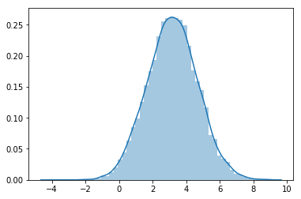

```python
# Import norm, matplotlib.pyplot, and seaborn
from scipy.stats import norm
import matplotlib.pyplot as plt
import seaborn as sns

# Create the sample using norm.rvs()
sample = norm.rvs(loc=3.15, scale=1.5, size=10000, random_state=13)

# Plot the sample
sns.distplot(a=sample, hist=True)
plt.show()
```

### Normal probabilities

```python
#Import norm
from scipy.stats import norm
```

```python
# Calculate th probability density
# with pdf
norm.pdf(-1, loc=0, scale=1)
```

```
0.24197072451914337
```

```python
# probability of all the values less than -1
# norm.cdf()
norm.cdf(-1)
```

```
0.15865525393145707
```

```python
# if you want to know how probable is to get a value of less than 0.5
norm.cdf(0.5)
```

```
0.6914624612740131
```

```python
# to calculate the percent point function (ppf)
# or the value where a given probability is accumulated
norm.ppf(0.2)
```

```
-0.8416212335729142
```

```python
norm.ppf(0.691463)
```

```
0.5000015301881557
```

### ppf() is the inverse of cdf()

```python
# probability betwee two values
a=-1
b=1
# calculate the probability between the two values
norm.cdf(b)-norm.cdf(a)
```

```
0.6826894921370859
```

```python
# Tail probability
# create the variable
# (the probability of geting a value greater then 1)
a=1
# calculate the complement of cdf() using sf()
norm.sf(a)
```

```
0.15865525393145707
```

```python
# calculate the probability of getting
# a value less than -2 and greater than 2
a=-2
b=2
norm.cdf(-2)+norm.sf(2)
```

```
0.04550026389635839
```

### Intervals

```python
# norm.cdf(b)-norm.cdf(a)=0.95?
alpha=0.95
norm.interval(alpha)
```

```
(-1.959963984540054, 1.959963984540054)
```

#### Restaurant spending example

Let's go back to the example of the restaurant chain that has been collecting data about customer spending. Recall that the data shows that the spending is approximately normally distributed, with a mean of 3.15 and a standard deviation of 1.5 per customer, as pictured in the plot.

- What is the probability that a customer will spend 3 dollars or less?

```python
# Probability of spending $3 or less
spending = norm.cdf(3, loc=3.15, scale=1.5)
print(spending)
```

```
0.46017216272297107
```

- What is the probability that a customer will spend more than $5?

```python
# Probability of spending more than $5
spending = norm.sf(5, loc=3.15, scale=1.5)
print(spending)
```

```
0.10872571321259111
```

- What is the probability that a customer will spend more than 2.15 and 4.15 or less?

```python
# Probability of spending more than $2.15 and $4.15 or less
spending_4 = norm.cdf(4.15, loc=3.15, scale=1.5)
spending_2 = norm.cdf(2.15, loc=3.15, scale=1.5)
print(spending_4 - spending_2)
```

```
0.4950149249061543
```

- What is the probability that a customer will spend 2.15 or less or more than 4.15?

```python
# Probability of spending $2.15 or less or more than $4.15
spending_2 = norm.cdf(2.15, loc=3.15, scale=1.5)
spending_over_4 = norm.sf(4.15  , loc=3.15, scale=1.5)
print(spending_2 + spending_over_4)
```

```
0.5049850750938457
```

#### Smartphone battery example

One of the most important things to consider when buying a smartphone is how long the battery will last.

Suppose the period of time between charges can be modeled with a normal distribution with a mean of 5 hours and a standard deviation of 1.5 hours.

A friend wants to buy a smartphone and is asking you the following questions.

(norm is already imported from scipy.stats.)

- What is the probability that the battery will last less than 3 hours?

```python
# Probability that battery will last less than 3 hours
less_than_3h = norm.cdf(3, loc=5, scale=1.5)
print(less_than_3h)
```

```
0.09121121972586788
```

- What is the probability that the battery will last more than 3 hours?

```python
# Probability that battery will last more than 3 hours
more_than_3h = norm.sf(3, loc=5, scale=1.5)
print(more_than_3h)
```

```
0.9087887802741321
```

- What is the probability that the battery will last between 5 and 7 hours?

```python
# Probability that battery will last between 5 and 7 hours
P_less_than_7h = norm.cdf(7, loc=5, scale=1.5)
P_less_than_5h = norm.cdf(5, loc=5, scale=1.5)
print(P_less_than_7h - P_less_than_5h)
```

```
0.4087887802741321
```

#### Adults' heights example

```python
# Values one standard deviation from mean height for females
interval = norm.interval(0.68, loc=65, scale=3.5)
print(interval)
```

```
(61.51939740876586, 68.48060259123413)
```

```python
# Value where the tallest males fall with 0.01 probability
tallest = norm.ppf(0.99, loc=70, scale=4)
print(tallest)
```

```
79.30539149616337
```

```python
# Probability of being taller than 73 inches for males and females
P_taller_male = norm.sf(73, loc=70, scale=4)
P_taller_female = norm.sf(73, loc=65, scale=3.5)
print(P_taller_male, P_taller_female)
```

```
0.2266273523768682 0.011135489479616392
```

```python
# Probability of being shorter than 61 inches for males and females
P_shorter_male = norm.cdf(61, loc=70, scale=4)
P_shorter_female = norm.cdf(61, loc=65, scale=3.5)
print(P_shorter_male, P_shorter_female)
```

```
0.012224472655044696 0.12654895447355774
```

### Poisson distributions

can model a frequency at which an event occures during a fixed interval of time (call center calls/ visiting a bank branch/ finishing a course on datacamp,...) properties

- outcomes can be classified as successes or failures
- average number of successful events per units is known

```python
# Import poisson
from scipy.stats import poisson
# calculate the probability mass with pmf
poisson.pmf(k=3, mu=2.2)
```

```
0.19663867170702193
```

```python
# probability of no calls in a minute
poisson.pmf(k=0, mu=2.2)
```

```
0.11080315836233387
```

```python
# probability of 6 calls in a minute
poisson.pmf(k=6, mu=2.2)
```

```
0.01744840480280308
```

```python
# calculate the probability of 2 or less calls per minute
poisson.cdf(k=2, mu=2.2)
```

```
0.6227137499963162
```

```python
# calculate the probability of 5 or less calls per minute
poisson.cdf(k=5, mu=2.2)
```

```
0.9750902496952996
```

```python
# calculate the probability of more than 2 calls per minute
poisson.sf(k=2, mu=2.2)
```

```
0.3772862500036838
```

```python
# calculate ppf of 0.5
poisson.ppf(q=0.5, mu=2.2)
```

```
2.0
```

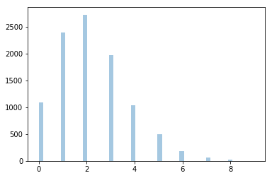

```python
### Sample generation (rvs)
from scipy.stats import poisson
import matplotlib.pyplot as plt
import seaborn as sns

# create the sample using poisson.rvs()
sample=poisson.rvs(mu=2.2, size=10000, random_state=13)

# plot the sample
sns.distplot(sample, kde=False)
plt.show()
```

### ATM example

If you know how many specific events occurred per unit of measure, you can assume that the distribution of the random variable follows a Poisson distribution to study the phenomenon.

Consider an ATM (automatic teller machine) at a very busy shopping mall. The bank wants to avoid making customers wait in line to use the ATM. It has been observed that the average number of customers making withdrawals between 10:00 a.m. and 10:05 a.m. on any given day is 1.

As a data analyst at the bank, you are asked what the probability is that the bank will need to install another ATM to handle the load.

To answer the question, you need to calculate the probability of getting more than one customer during that time period.

- Calculate the probability of having more than one customer visiting the ATM in this 5-minute period.

```python
# Import poisson from scipy.stats
from scipy.stats import poisson

# Probability of more than 1 customer
probability = poisson.sf(k=1, mu=1)

# Print the result
print(probability)
```

```
0.2642411176571153
```

### Highway accidents example

Aiming to improve road safety, the transportation agency of the regional government has assigned you the following tasks.

- Determine and print the probability of there being 5 accidents on any day.

```python
# Import the poisson object
from scipy.stats import poisson

# Probability of 5 accidents any day
P_five_accidents = poisson.pmf(k=5, mu=2)

# Print the result
print(P_five_accidents)
```

```
0.03608940886309672
```

- Determine and print the probability of having 4 or 5 accidents on any day.

```python
# Import the poisson object
from scipy.stats import poisson

# Probability of having 4 or 5 accidents on any day
P_less_than_6 = poisson.cdf(k=5, mu=2)
P_less_than_4 = poisson.cdf(k=3, mu=2)

# Print the result
print(P_less_than_6 - P_less_than_4)
```

```
0.12631293102083851
```

- Determine and print the probability of having more than 3 accidents on any day.

```python
# Import the poisson object
from scipy.stats import poisson

# Probability of more than 3 accidents any day
P_more_than_3 = poisson.sf(k=3, mu=2)

# Print the result
print(P_more_than_3)
```

```
0.14287653950145296
```

- Determine and print the number of accidents that is likely to happen with 0.75 probability.

```python
# Import the poisson object
from scipy.stats import poisson

# Number of accidents with 0.75 probability
accidents = poisson.ppf(q=0.75, mu=2)

# Print the result
print(accidents)
```

```
3.0
```

### Generating and plotting Poisson distributions

In the previous exercise, you calculated some probabilities. Now let's plot that distribution.

Recall that on a certain highway turn, there are 2 accidents per day on average. Assuming the number of accidents per day can be modeled as a Poisson random variable, let's plot the distribution.

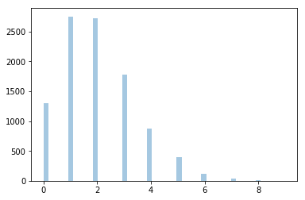

```python
# Import poisson, matplotlib.pyplot, and seaborn
from scipy.stats import poisson
import matplotlib.pyplot as plt
import seaborn as sns

# Create the sample
sample = poisson.rvs(mu=2, size=10000, random_state=13)

# Plot the sample
sns.distplot(sample, kde=False)
plt.show()
```

### Geometric distributions

In probability theory and statistics, the geometric distribution is either one of two discrete probability distributions:

- The probability distribution of the number X of Bernoulli trials needed to get one success, supported on the set { 1, 2, 3, ... }
- The probability distribution of the number Y = X − 1 of failures before the first success, supported on the set { 0, 1, 2, 3, ... }

Which of these one calls "the" geometric distribution is a matter of convention and convenience.

Consider a sequence of trials, where each trial has only two possible outcomes (designated failure and success). The probability of success is assumed to be the same for each trial. In such a sequence of trials, the geometric distribution is useful to model the number of failures before the first success. The distribution gives the probability that there are zero failures before the first success, one failure before the first success, two failures before the first success, and so on.

#### Assumptions: When is the geometric distribution an appropriate model?

The geometric distribution is an appropriate model if the following assumptions are true.

- The phenomenon being modeled is a sequence of independent trials.
- There are only two possible outcomes for each trial, often designated success or failure.
- The probability of success, p, is the same for every trial.

```python
# The probability of a bear catching a salmon is 0.0333.
# What is the probability that the bear will catch a salmon after 30 trails?
# Import geom
from scipy.stats import geom

# Calculate the probability mass
# with pmf; p is the probability of success
geom.pmf(k=30, p=0.0333)
```

```
0.012471080216374412
```

```python
# probability of bascetball player scoring in 4 or fewer attempts?
# use the geom.cdf().

geom.cdf(k=4, p=0.3)
```

```
0.7599
```

```python
# probability of basketball player scoring in 3 or more attempts?
# use geom.sf().

geom.sf(k=2, p=0.3)
```

```
0.49
```

```python
# to calculate the value where you accumulate a given probability use geom.ppf().
# ppf of 0.6.  (From probability to value)
geom.ppf(q=0.6, p=0.3)
```

```
3.0
```

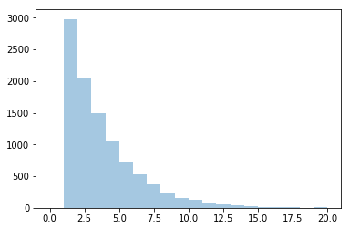

```python
# Sample generation
# Import poisson, matplotlib.pyplot, and seaborn
from scipy.stats import geom
import matplotlib.pyplot as plt
import seaborn as sns
import numpy as np

# Create the sample using geom.rvs()
sample = geom.rvs(p=0.3, size=10000, random_state=13)

# Plot the sample
sns.distplot(a=sample, bins = np.linspace(0,20,21), kde=False)
plt.show()
```

#### Catching salmon example

Every fall the salmon run occurs -- this is the time when salmon swim back upriver from the ocean to spawn. While swimming back to the upper river (usually to the place where they were spawned), the fish may encounter grizzly bears. Some of these bears can eat 18 salmon in 3 hours, and they have a 0.0333 probability of success in their attempts to catch a fish.

We can model a grizzly bear catching salmon with a geometric distribution.

- Calculate and print the probability that the bear will catch a salmon on its third attempt, after failing two times.

```python
# Getting a salmon on the third attempt
probability = geom.pmf(k=3, p=0.0333)

# Print the result
print(probability)
```

```
0.031119146037000004
```

- Calculate and print the probability that the bear will get a salmon in less than 5 attempts.

```python
# Probability of getting a salmon in less than 5 attempts
probability = geom.cdf(k=4, p=0.0333)

# Print the result
print(probability)
```

```
0.1266931345109679
```

- Calculate and print the probability that the bear will get a salmon in less than 21 attempts.

```python
# Probability of getting a salmon in less than 21 attempts
probability = geom.cdf(k=20, p=0.0333)

# Print the result
print(probability)
```

```
0.4920343187252892
```

- Calculate and print how many attempts the bear has to make to have a 0.9 probability of catching a salmon.

```python
# Attempts for 0.9 probability of catching a salmon
attempts = geom.ppf(q=0.9, p=0.0333)

# Print the result
print(attempts)
```

```
68.0
```

#### Free throws example

Suppose you know that a basketball player has a 0.3 probability of scoring a free throw. What is the probability of them missing with the first throw and scoring with the second?

```python
# Import geom from scipy.stats
from scipy.stats import geom

# Probability of missing first and scoring on second throw
probability = geom.pmf(k=2, p=0.3)

# Print the result
print(probability)
```

```
0.21
```

#### Generating and plotting geometric distributions

In sports it is common for players to make multiple attempts to score points for themselves or their teams. Each single attempt can have two possible outcomes, scoring or not scoring. Those situations can be modeled with geometric distributions. With scipy.stats you can generate samples using the rvs() function for each distribution.

Consider the previous example of a basketball player who scores free throws with a probability of 0.3. Generate a sample, and plot it.

- Import geom from scipy.stats, matplotlib.pyplot as plt, and seaborn as sns.
- Generate a sample with size=10000 from a geometric distribution with a probability of success of 0.3.
- Plot the sample generated.

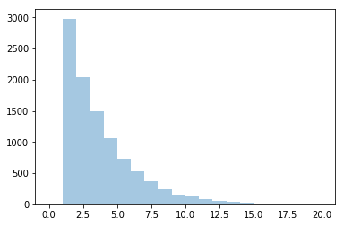

```python
# Import geom, matplotlib.pyplot, and seaborn
from scipy.stats import geom
import matplotlib.pyplot as plt
import seaborn as sns

# Create the sample
sample = geom.rvs(p=0.3, size=10000, random_state=13)

# Plot the sample
sns.distplot(sample, bins = np.linspace(0,20,21), kde=False)
plt.show()
```